# Exploratory Analysis

John Ho, Lucy Lin, Brianna Pak, Devina Tavathia, Kelly Wang

11/1/2021

Libraries Used:

```
library(dplyr)
library(ggplot2)
library(gridExtra)
library(readr)
library(tidyverse)
```

## Introductory Paragraph

Our group wanted to analyze the trends and correlations, if any, from homicide cases recorded in three regional scopes: nationally in the U.S., in Washington state, and in the city Seattle, Washington. The data came from [Kaggle](https://www.kaggle.com/murderaccountability/homicide-reports?select=database.csv), which features 24 separate columns as an overview of details and 638,454 cases.

- The Kaggle data was collected by the FBI’s Supplementary Homicide Report and Freedom of Information Act and compiled by the Murder Accountability Project. It is stated that the database contains homicides dating back to 1980 plus the 22,000 not reported to the Justice Department, with classifications on race, sex, and age of both perpetrators and victims.

We wanted to explore the information through filtering data for details we would need. Things such as categorizations of the perpetrator and victim, weapons used, areas with higher homicide rates, span of years and number of murders happening, all of this information was used to answer our research queries.

### Summary Information

Here are some questions we thought of when planning our project:

- How do factors of the perpetrator and victim (ex. age, race, etc.) correlate?
- Are there trends between perpetrator age and homicide type?
- What are the comparisons of homicide rates between other states?
- Which cities of each state have the most homicide cases? Any concentrations?
- How do current homicide rates within this decade compare to rates from previous decades (ex. 2000-2010, 1990-2000)?

These questions branched into more and more questions as we sorted through our data. Some statistics we sought out for were:

- Average age of murder victims in Washington State
- Numbers of cities with lowest number of homicide cases
- Largest number of homicides in a single state
- Number of descriptions/categories (columns) in our data frame
- Number of total cases (rows) altogether

### Summary Table

```
## $`Average Victim Age`
## [1] 13
##
## $`Highest number of homicides reported in a single city for each state`
## # A tibble: 51 x 2
##    State                MaxHomicide
##    <chr>                      <int>
##  1 Alabama                    23676
##  2 Alaska                      1225
##  3 Arizona                    53010
##  4 Arkansas                    7258
##  5 California                869135
##  6 Colorado                    9927
##  7 Connecticut                 3188
##  8 Delaware                    1159
##  9 District of Columbia      133621
## 10 Florida                  1511756
## # ... with 41 more rows
##
## $`Amount of cities with the smallest number of homicides`
## [1] 53
##
## $`Largest number of homicides (across all years, cumulative) in a single state`
## # A tibble: 1 x 2
##   State   MaxHomicide
##   <chr>         <int>
## 1 Florida     8100400
##
## $`Number of Columns`
## [1] 24
##
## $`Number of Rows`
## [1] 638454
```

```
##   Average_Victim_Age Amount_of_Cities_With_The_Smallest_Number_of_Homicides
## 1                 13                                                     53
##   Largest_Number_of_Homicides_in_a_Single_State Number_of_Columns
## 1                                       8100400                24
##   Number_of_Rows
## 1         638454
```

### Homicide Counts Over the Years

One takeaway is that the sheer number of homicide cases in the last two decades shadow over the amounts in the 1980s and 1990s, with the amount essentially doubling in total.

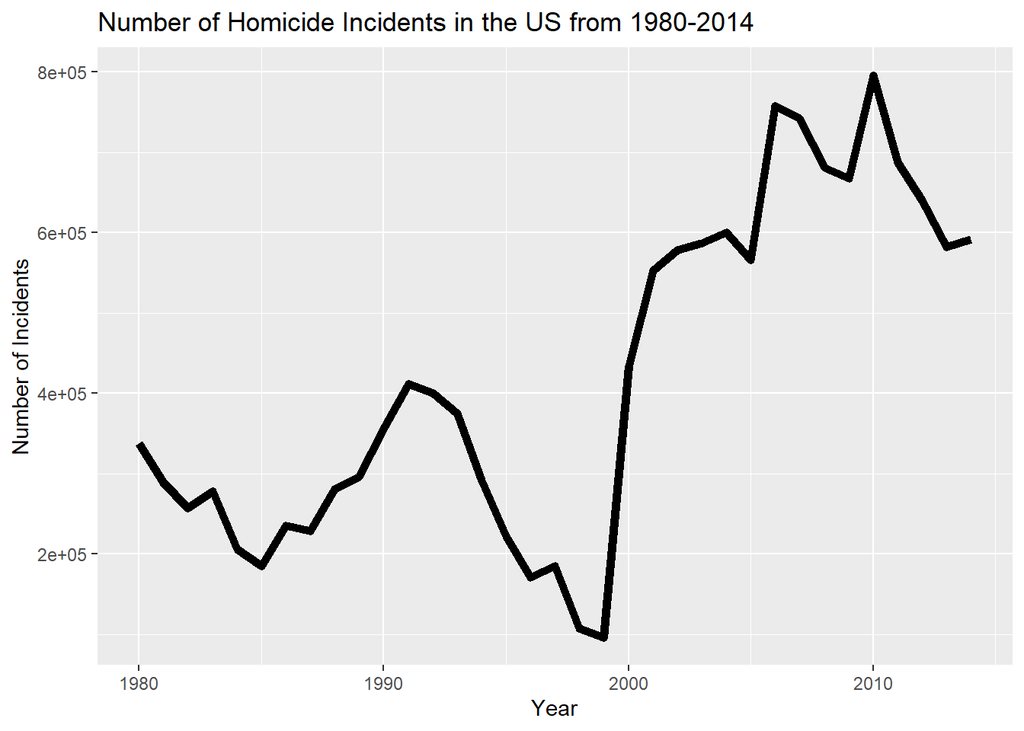

### Distribution of Ages of Victims and Perpetrators

It is important for us to see the age distribution of both homicide victims and perpetrators to notice trends or a certain demographic that account for the number of cases.

For victim ages, there is a visual bar for any age group from age 1 to 95, it crossed the entire domain of range. The most frequent age group in victims was 15-20 years old, the ages of teenagers and young adults. The distribution past age 20 was a very gradual decline even past the age of 80, skewed to the right. What is disturbing is that there is a consider amount of victims under the age of 10, young children and babies, around the count of 125 each.

As for the perpetrators, the histogram looks very similar to the histogram for victims, minus the two bars of those who are 1-10 years old. Just like the distribution of victim ages, the ages of perpetrators had the same frequency or shape in its groupings: 15-20 being the large majority of the graph with a higher peak (~2900 perpetrators compared to ~1750 victims), and having a right skew but only to the noticeable range of 60 years old (past this point has very slight numbers).

The ages of homicide victims were spread much more than the age of perpetrators, having more range and “even” distribution. General speculations could be that younger victims are easier targets (mentioned in summary description) or manipulable by older perpetrators, as the balance of power is in favor for the perpetrators that way.

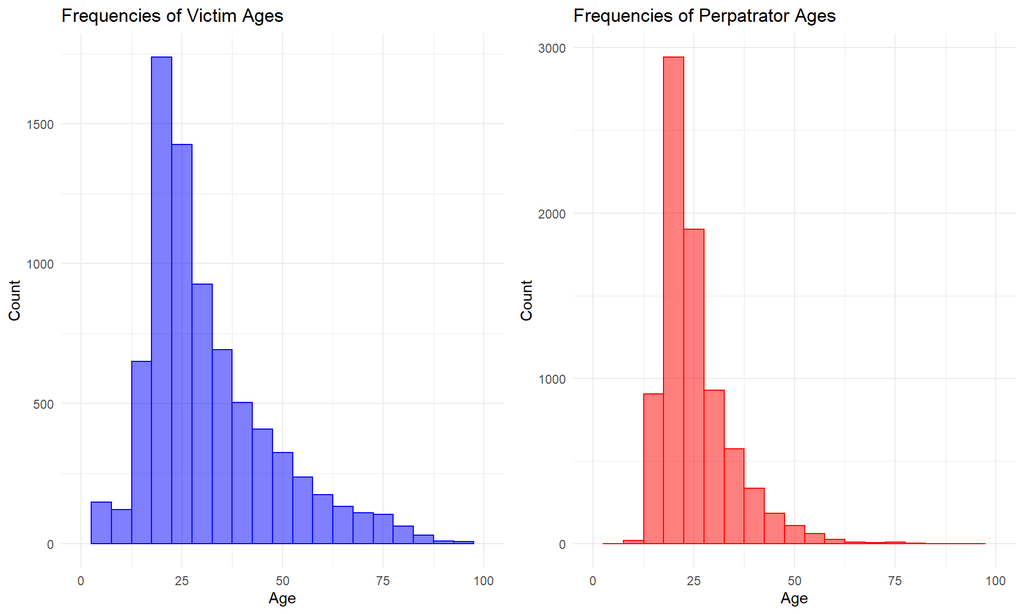

### Popular Weapons Used in Homicide

We wanted to investigate if there was a more commonly used weapon within all homicide cases, and what types of weapons were recorded in the first place.

It shows that the majority of perpetrators who carry out homicides have access to some sort of firearm weapon, and the handgun would be the most accessible to use. As assault rifles and shotguns are bigger and harder-to-get guns than handguns, it gives a reason why handguns would be the alternative being just as, if not more, effective. Knives and blunt objects are not specified but both can be found in most households or establishments (as their purpose being tools), as their numbers are noteworthy in the bar graph.

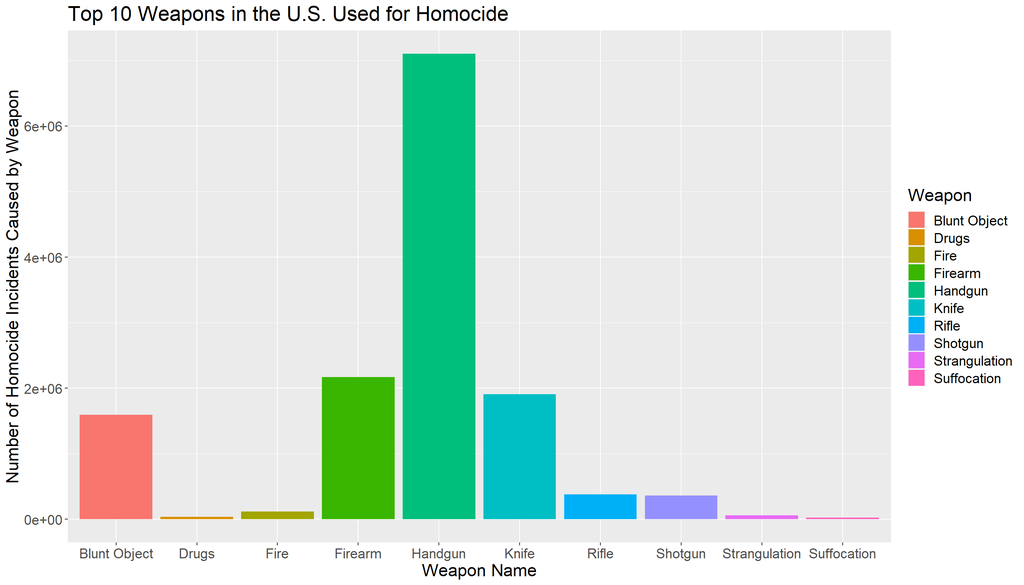

### Closing Thoughts

There are general trends we can pull from the visualisation and interpretation from the homicide data provided by the FBI.

- The number of homicide cases have been at a stable high compared to the amount in the late 1900’s.
- Teenagers and young adults have the most victims and perpetrators out of any age group.
- Handguns are the most frequently used weapon in homicides, with other lethal weapons such as knives, blunt objects, and other guns following.

There are many factors that can be put into consideration with these trends. Homicides are mostly done with accessible weapons, either from the perpetrator themselves or the environment around them (ex. knives, blunt objects). Gun control and regulations has been an ongoing conflict and political discussion in U.S. society, being said to be *easy* for an individual to own a gun. Connecting this to gun culture in the media and U.S. itself, it is tied to a popular culture that distributes to many types of killings. Mass shootings, school shootings, gang shootings, hate crime shootings, it is not suprising to see unlawful actions being done with an easy-access lethal weapon. Gun ownership could be higher in the U.S. now in comparison to decades ago, and could be the reason why there is a higher amount of homicides recently than in the past shown in the line graph.

The exploitation of power, or power imbalance, can describe the distribution of older perpetrators to younger or elderly victims. The victims could not fight back or have been in a relationship where there is no reinforced power for them to defend themselves. Youth violence and childhood experiences could shape up adolescents and young adults to execute acts of homicides, having motives or the violent culture behind them. Leading back to U.S. gun and violent culture, this could cultivate both the cumulative amount of homicide cases per year, in addition to the age groups that commit them.

There are many details in the data sheet, such as victim’s relationship to perpetrator, race and sex of victims and perpetrators, victim count of the perpetrator, and crime type that can be explored respectively for more detailed analysis on all recorded crime cases. However, our group focused on providing an overview of homicide cases in the U.S. and noting any trends from the information that is gathered and visualised.